# assignment-4-hindispeechclassify

```python
# This Python 3 environment comes with many helpful analytics libraries installed
# It is defined by the kaggle/python Docker image: https://github.com/kaggle/docker-python
# For example, here's several helpful packages to load

import numpy as np # linear algebra
import pandas as pd # data processing, CSV file I/O (e.g. pd.read_csv)

# Input data files are available in the read-only "../input/" directory
# For example, running this (by clicking run or pressing Shift+Enter) will list all files under the input directory

import os
for dirname, _, filenames in os.walk('/kaggle/input'):
    for filename in filenames:
        #print(os.path.join(dirname, filename))
        pass

# You can write up to 20GB to the current directory (/kaggle/working/) that gets preserved as output when you create a version using "Save & Run All"
# You can also write temporary files to /kaggle/temp/, but they won't be saved outside of the current session
```

```python
import warnings
warnings.filterwarnings('ignore')
```

```python
df_train=pd.read_csv("../input/hindi-speech-classification/dataset/train.csv")
```

```python
df_train.head()
```

|  | file_id | gender |
| --- | --- | --- |
| 0 | common_voice_hi_26204093 | male |
| 1 | common_voice_hi_26043935 | male |
| 2 | common_voice_hi_24632150 | male |
| 3 | common_voice_hi_24359471 | female |
| 4 | common_voice_hi_24639127 | male |

```python
def FileRepos(tod,df):
    base_path="../input/hindi-speech-classification/dataset/"
    df["file_path"]=base_path+tod+"/"+df["file_id"]+".mp3"
    del df['file_id']
    return df
```

```python
df_train=FileRepos("train",df_train)
```

```python
df_train.head()
```

|  | gender | file_path |
| --- | --- | --- |
| 0 | male | ../input/hindi-speech-classification/dataset/t... |
| 1 | male | ../input/hindi-speech-classification/dataset/t... |
| 2 | male | ../input/hindi-speech-classification/dataset/t... |
| 3 | female | ../input/hindi-speech-classification/dataset/t... |
| 4 | male | ../input/hindi-speech-classification/dataset/t... |

```python
df_train["file_path"][0]
```

```
'../input/hindi-speech-classification/dataset/train/common_voice_hi_26204093.mp3'
```

```python
df_test=pd.read_csv("../input/hindi-speech-classification/dataset/test.csv")
```

```python
df_test=FileRepos("test",df_test)
```

```python
df_test.head()
```

|  | gender | file_path |
| --- | --- | --- |
| 0 | male | ../input/hindi-speech-classification/dataset/t... |
| 1 | male | ../input/hindi-speech-classification/dataset/t... |
| 2 | male | ../input/hindi-speech-classification/dataset/t... |
| 3 | male | ../input/hindi-speech-classification/dataset/t... |
| 4 | male | ../input/hindi-speech-classification/dataset/t... |

```python
df_test["file_path"][0]
```

```
'../input/hindi-speech-classification/dataset/test/common_voice_hi_26042241.mp3'
```

```python
import os
import librosa
import librosa.display
import matplotlib.pyplot as plt
```

```python
random_sample=[df_train['file_path'][0],df_train['file_path'][3]]
```

```python
random_sample
```

```
['../input/hindi-speech-classification/dataset/train/common_voice_hi_26204093.mp3',
 '../input/hindi-speech-classification/dataset/train/common_voice_hi_24359471.mp3']
```

```python
def AudioPlot(audio,name):
    plt.figure(figsize=(20,8))
    plt.subplots_adjust(hspace=0.8)
    x , sr = librosa.load(audio)
    plt.title(name+" - Zero Crossing Rate")
    zero_crossings = librosa.zero_crossings(x)
    zcrs = librosa.feature.zero_crossing_rate(x)
    #print(zcrs)
    plt.plot(zcrs[0])
```

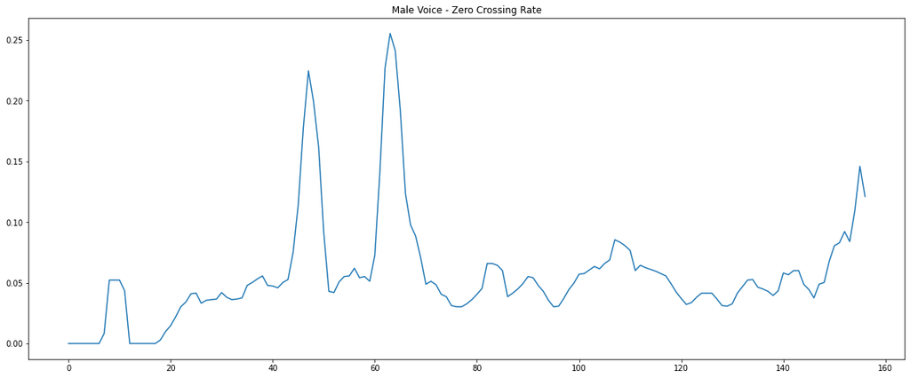

```python
AudioPlot(random_sample[0],"Male Voice")
```

**A large number of zero crossings implies that there is no dominant low-frequency oscillation. We see ample of zero crossing that shows the presence of speech.**

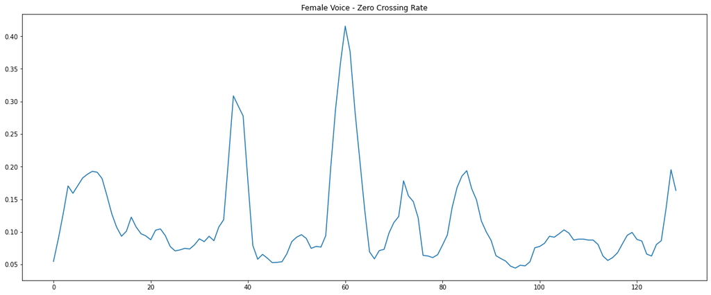

```python
AudioPlot(random_sample[1],"Female Voice")
```

**A large number of zero crossings implies that there is no dominant low-frequency oscillation. Large number of Zero crossings are observed here**

```python
def create_zcr_features(path):
    zcrs = []
    try:
        x , sr = librosa.load(path)
        zero_crossings = librosa.zero_crossings(x)
        zcrs = librosa.feature.zero_crossing_rate(x)
        #print(zcrs[0])
        zcrs=zcrs[0]
        #zcrs = np.mean(zcrs[0].T,axis=0)
    except:
        print('Error reading audio')
    return zcrs
```

```python
import warnings
warnings.filterwarnings('ignore')
```

```python
%%time
X_df = pd.DataFrame(df_train['file_path'].apply(lambda x: create_zcr_features(x)).tolist())
X_df.head()
```

```
CPU times: user 13min 10s, sys: 3min 40s, total: 16min 51s
Wall time: 21min 45s
```

|  | 0 | 1 | 2 | 3 | 4 | 5 | 6 | 7 | 8 | 9 | ... | 429 | 430 | 431 | 432 | 433 | 434 | 435 | 436 | 437 | 438 |
| --- | --- | --- | --- | --- | --- | --- | --- | --- | --- | --- | --- | --- | --- | --- | --- | --- | --- | --- | --- | --- | --- |
| 0 | 0.000000 | 0.000000 | 0.000000 | 0.000000 | 0.00000 | 0.000000 | 0.000000 | 0.008301 | 0.052246 | 0.052246 | ... | NaN | NaN | NaN | NaN | NaN | NaN | NaN | NaN | NaN | NaN |
| 1 | 0.000000 | 0.000000 | 0.000000 | 0.000000 | 0.00000 | 0.000000 | 0.000000 | 0.013672 | 0.071777 | 0.071777 | ... | NaN | NaN | NaN | NaN | NaN | NaN | NaN | NaN | NaN | NaN |
| 2 | 0.000000 | 0.000000 | 0.000000 | 0.000000 | 0.00000 | 0.000000 | 0.000000 | 0.000000 | 0.000000 | 0.000000 | ... | NaN | NaN | NaN | NaN | NaN | NaN | NaN | NaN | NaN | NaN |
| 3 | 0.054688 | 0.089355 | 0.127930 | 0.170410 | 0.15918 | 0.170898 | 0.182617 | 0.188477 | 0.192871 | 0.191406 | ... | NaN | NaN | NaN | NaN | NaN | NaN | NaN | NaN | NaN | NaN |
| 4 | 0.148926 | 0.307617 | 0.466797 | 0.622559 | 0.62793 | 0.621094 | 0.610352 | 0.570312 | 0.527832 | 0.504395 | ... | NaN | NaN | NaN | NaN | NaN | NaN | NaN | NaN | NaN | NaN |

5 rows × 439 columns

```python
X_df_zim=X_df.mask(X_df==0).fillna(0)
```

```python
X_df_zim.head()
```

|  | 0 | 1 | 2 | 3 | 4 | 5 | 6 | 7 | 8 | 9 | ... | 429 | 430 | 431 | 432 | 433 | 434 | 435 | 436 | 437 | 438 |
| --- | --- | --- | --- | --- | --- | --- | --- | --- | --- | --- | --- | --- | --- | --- | --- | --- | --- | --- | --- | --- | --- |
| 0 | 0.000000 | 0.000000 | 0.000000 | 0.000000 | 0.00000 | 0.000000 | 0.000000 | 0.008301 | 0.052246 | 0.052246 | ... | 0.0 | 0.0 | 0.0 | 0.0 | 0.0 | 0.0 | 0.0 | 0.0 | 0.0 | 0.0 |
| 1 | 0.000000 | 0.000000 | 0.000000 | 0.000000 | 0.00000 | 0.000000 | 0.000000 | 0.013672 | 0.071777 | 0.071777 | ... | 0.0 | 0.0 | 0.0 | 0.0 | 0.0 | 0.0 | 0.0 | 0.0 | 0.0 | 0.0 |
| 2 | 0.000000 | 0.000000 | 0.000000 | 0.000000 | 0.00000 | 0.000000 | 0.000000 | 0.000000 | 0.000000 | 0.000000 | ... | 0.0 | 0.0 | 0.0 | 0.0 | 0.0 | 0.0 | 0.0 | 0.0 | 0.0 | 0.0 |
| 3 | 0.054688 | 0.089355 | 0.127930 | 0.170410 | 0.15918 | 0.170898 | 0.182617 | 0.188477 | 0.192871 | 0.191406 | ... | 0.0 | 0.0 | 0.0 | 0.0 | 0.0 | 0.0 | 0.0 | 0.0 | 0.0 | 0.0 |
| 4 | 0.148926 | 0.307617 | 0.466797 | 0.622559 | 0.62793 | 0.621094 | 0.610352 | 0.570312 | 0.527832 | 0.504395 | ... | 0.0 | 0.0 | 0.0 | 0.0 | 0.0 | 0.0 | 0.0 | 0.0 | 0.0 | 0.0 |

5 rows × 439 columns

```python
from sklearn.impute import KNNImputer
```

```python
imputer = KNNImputer()
```

```python
imputer.fit(X_df)
```

```
KNNImputer()
```

```python
X_df_knn = imputer.transform(X_df)
```

```python
X_df_knn=pd.DataFrame(X_df_knn)
```

```python
X_df_knn.head()
```

|  | 0 | 1 | 2 | 3 | 4 | 5 | 6 | 7 | 8 | 9 | ... | 429 | 430 | 431 | 432 | 433 | 434 | 435 | 436 | 437 | 438 |
| --- | --- | --- | --- | --- | --- | --- | --- | --- | --- | --- | --- | --- | --- | --- | --- | --- | --- | --- | --- | --- | --- |
| 0 | 0.000000 | 0.000000 | 0.000000 | 0.000000 | 0.00000 | 0.000000 | 0.000000 | 0.008301 | 0.052246 | 0.052246 | ... | 0.098389 | 0.11084 | 0.114014 | 0.118896 | 0.124023 | 0.134766 | 0.147217 | 0.180664 | 0.165283 | 0.197754 |
| 1 | 0.000000 | 0.000000 | 0.000000 | 0.000000 | 0.00000 | 0.000000 | 0.000000 | 0.013672 | 0.071777 | 0.071777 | ... | 0.098389 | 0.11084 | 0.114014 | 0.118896 | 0.124023 | 0.134766 | 0.147217 | 0.180664 | 0.165283 | 0.197754 |
| 2 | 0.000000 | 0.000000 | 0.000000 | 0.000000 | 0.00000 | 0.000000 | 0.000000 | 0.000000 | 0.000000 | 0.000000 | ... | 0.098389 | 0.11084 | 0.114014 | 0.118896 | 0.124023 | 0.134766 | 0.147217 | 0.180664 | 0.165283 | 0.197754 |
| 3 | 0.054688 | 0.089355 | 0.127930 | 0.170410 | 0.15918 | 0.170898 | 0.182617 | 0.188477 | 0.192871 | 0.191406 | ... | 0.098389 | 0.11084 | 0.114014 | 0.118896 | 0.124023 | 0.134766 | 0.147217 | 0.180664 | 0.165283 | 0.197754 |
| 4 | 0.148926 | 0.307617 | 0.466797 | 0.622559 | 0.62793 | 0.621094 | 0.610352 | 0.570312 | 0.527832 | 0.504395 | ... | 0.098389 | 0.11084 | 0.114014 | 0.118896 | 0.124023 | 0.134766 | 0.147217 | 0.180664 | 0.165283 | 0.197754 |

5 rows × 439 columns

```python
from sklearn.decomposition import PCA
```

```python
pca = PCA()
```

```python
principalComponents = pca.fit_transform(X_df_zim)
```

```python
pca.explained_variance_ratio_.sum()
```

```
0.9999999999999998
```

```python
percent_var_explained = pca.explained_variance_/(np.sum(pca.explained_variance_))
cumm_var_explained = np.cumsum(percent_var_explained)
print(cumm_var_explained)
```

```
[0.22816091 0.3150828  0.38151407 0.429601   0.47371177 0.51163817
 0.5458888  0.57647926 0.60109873 0.6232738  0.64213275 0.6588451
 0.67452463 0.68903657 0.70344112 0.71685714 0.72847163 0.73997143
 0.75069512 0.76117691 0.77124759 0.78087569 0.79029582 0.79947045
 0.80843409 0.81665235 0.8245152  0.83229007 0.83934435 0.84636541
 0.85309377 0.85918851 0.86514217 0.87100694 0.87672251 0.88181317
 0.88656665 0.89112005 0.89562148 0.89978543 0.90369389 0.90753301
 0.91124214 0.91494335 0.91851376 0.92175732 0.92496406 0.9279307
 0.93078824 0.93355254 0.93624838 0.93883475 0.94136415 0.94379422
 0.94613962 0.94837441 0.95043709 0.95239027 0.95427552 0.95611895
 0.95791994 0.95961916 0.96122277 0.96280638 0.96432971 0.96574808
 0.96710896 0.96839899 0.96967517 0.97092044 0.97209147 0.97322536
 0.97429006 0.97530871 0.97628982 0.97718149 0.9780176  0.97884919
 0.97962573 0.98035738 0.98107073 0.98174295 0.98240366 0.98303625
 0.98362914 0.98422039 0.98477885 0.98530831 0.98583119 0.98632977
 0.98680535 0.98725535 0.98769651 0.98811861 0.98851367 0.98889282
 0.98926958 0.98962141 0.9899639  0.99029617 0.99062182 0.99093311
 0.99122701 0.99150748 0.99177353 0.99203242 0.99228944 0.99252753
 0.99275802 0.99298176 0.99319554 0.99340088 0.99359917 0.99378503
 0.99396639 0.9941429  0.99430594 0.99446623 0.99461814 0.99476557
 0.9949     0.99503331 0.99516038 0.99528442 0.99540204 0.99551493
 0.99562272 0.99572656 0.99582873 0.99592385 0.99601744 0.99610631
 0.99619091 0.99627055 0.99634915 0.99642456 0.99649827 0.99656703
 0.99663489 0.9967011  0.9967645  0.99682428 0.996883   0.9969404
 0.99699633 0.99704831 0.99709903 0.99714877 0.99719741 0.99724451
 0.99729099 0.99733607 0.99738019 0.99742427 0.99746644 0.99750795
 0.99754862 0.99758836 0.99762769 0.99766627 0.99770448 0.99774176
 0.99777836 0.9978146  0.9978504  0.99788497 0.9979193  0.99795315
 0.99798652 0.99801935 0.9980519  0.99808373 0.99811513 0.99814536
 0.9981748  0.99820399 0.9982328  0.99826075 0.99828848 0.99831583
 0.9983431  0.99836983 0.99839636 0.99842269 0.99844845 0.99847408
 0.99849958 0.99852452 0.9985492  0.99857331 0.9985972  0.99862067
 0.99864388 0.99866681 0.99868957 0.99871182 0.99873384 0.99875551
 0.99877704 0.99879821 0.99881866 0.99883892 0.9988589  0.99887853
 0.99889794 0.99891715 0.99893612 0.99895477 0.99897315 0.99899133
 0.99900947 0.99902716 0.99904448 0.99906168 0.99907852 0.99909519
 0.99911161 0.99912795 0.99914401 0.99915991 0.99917546 0.99919078
 0.99920595 0.99922101 0.99923586 0.99925047 0.99926475 0.9992787
 0.99929246 0.99930615 0.99931962 0.99933293 0.99934599 0.99935896
 0.99937168 0.99938432 0.99939678 0.99940902 0.99942112 0.99943305
```

[output cut: 19 more lines]

```
 0.99999653 0.99999694 0.9999973  0.99999764 0.99999796 0.99999825
 0.99999852 0.99999875 0.99999895 0.99999914 0.9999993  0.99999943
 0.99999953 0.99999961 0.99999968 0.99999975 0.99999981 0.99999986
 0.9999999  0.99999993 0.99999996 0.99999998 0.99999999 0.99999999
 1.         1.         1.         1.         1.         1.
 1.         1.         1.         1.         1.         1.
 1.         1.         1.         1.         1.         1.
 1.         1.         1.         1.         1.         1.
 1.         1.         1.         1.         1.         1.
 1.         1.         1.         1.         1.         1.
 1.         1.         1.         1.         1.         1.
 1.         1.         1.         1.         1.         1.
 1.         1.         1.         1.         1.         1.
 1.         1.         1.         1.         1.         1.
 1.        ]
```

```python
X_pca = pd.DataFrame(principalComponents)

X_pca.head()
```

|  | 0 | 1 | 2 | 3 | 4 | 5 | 6 | 7 | 8 | 9 | ... | 429 | 430 | 431 | 432 | 433 | 434 | 435 | 436 | 437 | 438 |
| --- | --- | --- | --- | --- | --- | --- | --- | --- | --- | --- | --- | --- | --- | --- | --- | --- | --- | --- | --- | --- | --- |
| 0 | -0.758371 | -0.039369 | 0.096803 | -0.148111 | -0.065619 | 0.094073 | 0.085369 | 0.013914 | -0.003518 | 0.011792 | ... | 1.053558e-16 | -1.014767e-16 | -1.312002e-16 | -1.941708e-17 | 3.094623e-17 | -2.356201e-17 | 9.862209e-18 | 1.118544e-16 | 8.889484e-17 | 5.084503e-16 |
| 1 | -0.468756 | -0.199873 | 0.181585 | 0.082558 | -0.148450 | 0.037340 | 0.231982 | -0.114463 | -0.121369 | -0.003185 | ... | -2.643744e-16 | 1.069852e-16 | -8.601027e-17 | 9.378679e-17 | 2.591961e-16 | 2.232257e-18 | -2.926474e-17 | -1.010052e-16 | -4.680873e-17 | -1.716789e-16 |
| 2 | 1.097367 | -1.095163 | -0.306566 | -0.655565 | -0.493391 | 0.845137 | 0.897393 | -0.970064 | -0.089883 | -0.215540 | ... | 5.945553e-18 | 6.777660e-19 | 2.236091e-18 | 2.452279e-18 | 1.142160e-19 | 1.603736e-18 | 1.180271e-18 | 3.484194e-18 | -5.695114e-19 | -3.449437e-18 |
| 3 | -0.308732 | 0.294423 | -0.212587 | 0.144208 | 0.151917 | 0.092427 | 0.115992 | -0.008326 | 0.148873 | -0.215367 | ... | 2.745764e-16 | 3.994279e-17 | -1.099872e-16 | 2.673433e-17 | -6.268717e-17 | -2.486708e-16 | -2.742654e-17 | -1.753271e-16 | -1.353530e-16 | 1.978207e-17 |
| 4 | 2.226811 | 0.382371 | 1.856384 | -0.363235 | 0.220474 | 0.321070 | -0.670470 | 0.307124 | 0.208799 | -0.231058 | ... | 1.273384e-17 | -1.893703e-16 | -2.016771e-16 | 9.012782e-17 | 1.070863e-16 | -5.136957e-17 | -2.838501e-16 | 1.910966e-16 | -1.259891e-16 | 3.234050e-16 |

5 rows × 439 columns

```python
X_pca.iloc[:, :2]
```

|  | 0 | 1 |
| --- | --- | --- |
| 0 | -0.758371 | -0.039369 |
| 1 | -0.468756 | -0.199873 |
| 2 | 1.097367 | -1.095163 |
| 3 | -0.308732 | 0.294423 |
| 4 | 2.226811 | 0.382371 |
| ... | ... | ... |
| 1993 | 0.975175 | 0.735672 |
| 1994 | -0.769633 | -0.031676 |
| 1995 | 0.530097 | 1.199645 |
| 1996 | 0.103562 | -0.202746 |
| 1997 | -0.423095 | 0.099257 |

1998 rows × 2 columns

```python
from sklearn.cluster import KMeans, AgglomerativeClustering, DBSCAN
```

```python
import seaborn as sns
```

```python
import plotly as py
import plotly.graph_objs as go
```

```python
principalDf = pd.DataFrame(data = X_pca.iloc[:, :2])
principalDf.columns=['PCA 1','PCA 2']
```

```python
principalDf.head()
```

|  | PCA 1 | PCA 2 |
| --- | --- | --- |
| 0 | -0.758371 | -0.039369 |
| 1 | -0.468756 | -0.199873 |
| 2 | 1.097367 | -1.095163 |
| 3 | -0.308732 | 0.294423 |
| 4 | 2.226811 | 0.382371 |

```python
kmeans = KMeans(n_clusters = 2, init = 'k-means++', random_state = 42)
y_kmeans = kmeans.fit_predict(X_pca.iloc[:, :2])
```

```python
finalDf = pd.concat([principalDf, pd.DataFrame(y_kmeans,columns=['target'])], axis = 1)
```

```python
finalDf.head()
```

|  | PCA 1 | PCA 2 | target |
| --- | --- | --- | --- |
| 0 | -0.758371 | -0.039369 | 1 |
| 1 | -0.468756 | -0.199873 | 1 |
| 2 | 1.097367 | -1.095163 | 0 |
| 3 | -0.308732 | 0.294423 | 1 |
| 4 | 2.226811 | 0.382371 | 0 |

```python
trace1 = go.Scatter(
    x= finalDf['PCA 1'],
    y= finalDf['PCA 2'],
    #z= finalDf['PCA 3'],
    mode='markers',
     marker=dict(
        color = y_kmeans,
        size= 10,
        line=dict(
            color= y_kmeans,
            width= 12
        ),
        opacity=0.8
     )
)
data_plotly = [trace1]
layout = go.Layout(
    title= 'Clusters wrt two PCA Components',
    scene = dict(
            xaxis = dict(title  = 'PCA 0'),
            yaxis = dict(title  = 'PCA 1'),
            #zaxis = dict(title  = 'PCA 3'),
        )
)
fig = go.Figure(data=data_plotly, layout=layout)
fig.show()
```

[interactive chart not shown]

```python
pc_knn = pca.fit_transform(X_df_knn)
```

```python
pca.explained_variance_ratio_.sum()
```

```
1.0
```

```python
percent_var_explained = pca.explained_variance_/(np.sum(pca.explained_variance_))
cumm_var_explained = np.cumsum(percent_var_explained)
print(cumm_var_explained)
```

```
[0.35094291 0.4096462  0.45902682 0.49649293 0.53308548 0.56092276
 0.58646575 0.60829627 0.62779189 0.64573741 0.66152429 0.67568151
 0.68955783 0.70254706 0.7148036  0.72599655 0.73629644 0.74643646
 0.75611508 0.76545621 0.77466883 0.78334144 0.79170532 0.79952527
 0.8071549  0.81443375 0.82162691 0.82852306 0.83519109 0.84154394
 0.84752092 0.8531388  0.85862746 0.86378971 0.86873846 0.87355438
 0.87820412 0.88249545 0.88664286 0.89066079 0.89460734 0.8983719
 0.90189296 0.90535041 0.90877038 0.91197744 0.91515597 0.91821673
 0.92113786 0.9239698  0.92672503 0.92932158 0.9318479  0.93428029
 0.93661981 0.93891823 0.9411038  0.9432472  0.9453336  0.94727545
 0.94921509 0.95107209 0.95284343 0.95454768 0.95620042 0.95779009
 0.95934033 0.96080663 0.96222164 0.96355743 0.9648717  0.96610236
 0.96731981 0.96850784 0.9696419  0.97071496 0.97176067 0.97276579
 0.97374568 0.97465722 0.97554843 0.97639257 0.97720921 0.97796034
 0.97870026 0.97942976 0.98011175 0.98078664 0.98143278 0.98205497
 0.98266402 0.98324652 0.9838133  0.98436278 0.98489466 0.98539434
 0.98586948 0.98632816 0.98678005 0.98720223 0.98761949 0.988004
 0.98838115 0.98873847 0.98909395 0.98944041 0.9897614  0.9900688
 0.99037268 0.99065366 0.99092175 0.99118374 0.99143959 0.99168746
 0.99193038 0.99216812 0.99239214 0.99261214 0.99281934 0.99301855
 0.99321182 0.99339539 0.99357266 0.99374484 0.99390939 0.99406711
 0.99421753 0.99436053 0.9944984  0.99463245 0.99475925 0.99488186
 0.9950004  0.99510727 0.99521247 0.99531634 0.99541907 0.99551806
 0.99561644 0.99571096 0.9957982  0.99588332 0.99596747 0.99604755
 0.99612388 0.99619923 0.99627255 0.99634223 0.99640816 0.99647302
 0.99653676 0.99659933 0.99665929 0.99671741 0.99677447 0.99682956
 0.99688203 0.99693325 0.99698341 0.9970318  0.99707884 0.99712401
 0.99716824 0.99721185 0.99725386 0.99729482 0.99733518 0.99737428
 0.99741276 0.99745083 0.9974883  0.99752519 0.99756067 0.99759574
 0.99762993 0.9976639  0.99769743 0.99773048 0.99776279 0.99779466
 0.99782546 0.99785624 0.99788609 0.99791564 0.99794498 0.99797393
 0.99800277 0.99803079 0.99805846 0.99808589 0.99811283 0.99813932
 0.99816554 0.99819146 0.99821679 0.99824198 0.99826695 0.99829158
 0.99831599 0.99833999 0.9983634  0.99838664 0.99840983 0.99843271
 0.99845543 0.99847769 0.99849973 0.99852155 0.99854318 0.9985644
 0.99858543 0.99860627 0.99862707 0.99864783 0.99866815 0.99868811
 0.99870766 0.99872706 0.99874613 0.99876505 0.99878378 0.99880202
 0.99882002 0.99883779 0.99885549 0.99887295 0.99889021 0.99890732
 0.99892402 0.99894054 0.99895694 0.99897304 0.99898892 0.99900467
 0.99902025 0.99903578 0.99905099 0.99906615 0.99908102 0.99909573
```

[output cut: 19 more lines]

```
 0.99994505 0.99994742 0.99994969 0.99995193 0.99995411 0.9999562
 0.99995822 0.99996022 0.99996215 0.99996404 0.99996587 0.99996764
 0.99996935 0.999971   0.9999726  0.99997417 0.99997571 0.99997719
 0.99997864 0.99998005 0.99998133 0.99998261 0.99998383 0.99998501
 0.99998611 0.99998718 0.99998823 0.99998926 0.99999024 0.99999118
 0.99999206 0.99999292 0.99999373 0.9999945  0.99999523 0.99999587
 0.99999644 0.99999695 0.99999745 0.99999791 0.99999829 0.99999865
 0.99999892 0.99999912 0.9999993  0.99999947 0.99999961 0.99999975
 0.99999983 0.9999999  0.99999995 0.99999998 1.         1.
 1.         1.         1.         1.         1.         1.
 1.         1.         1.         1.         1.         1.
 1.         1.         1.         1.         1.         1.
 1.         1.         1.         1.         1.         1.
 1.         1.         1.         1.         1.         1.
 1.        ]
```

```python
X_pca_knn = pd.DataFrame(pc_knn)

X_pca_knn.head()
```

|  | 0 | 1 | 2 | 3 | 4 | 5 | 6 | 7 | 8 | 9 | ... | 429 | 430 | 431 | 432 | 433 | 434 | 435 | 436 | 437 | 438 |
| --- | --- | --- | --- | --- | --- | --- | --- | --- | --- | --- | --- | --- | --- | --- | --- | --- | --- | --- | --- | --- | --- |
| 0 | -0.923332 | -0.047261 | 0.062369 | 0.122029 | -0.024794 | 0.107132 | -0.045735 | -0.129471 | 0.039800 | -0.102179 | ... | -4.085014e-17 | 1.119431e-17 | 8.941635e-17 | 3.732848e-17 | 6.737466e-17 | -6.875335e-17 | -4.618697e-17 | -7.853175e-17 | 3.552536e-17 | 6.615938e-17 |
| 1 | -0.845137 | -0.000493 | -0.044179 | 0.172403 | -0.070495 | 0.020929 | -0.017570 | -0.112072 | 0.143395 | -0.098346 | ... | 9.671026e-17 | -1.355971e-16 | 1.572893e-16 | 1.259032e-17 | 8.309491e-18 | 2.431104e-17 | 8.788683e-17 | 3.694028e-17 | -1.056669e-18 | 5.102632e-16 |
| 2 | 0.527634 | 0.130736 | 0.260096 | 1.013400 | 0.118680 | 0.578905 | 0.449838 | -0.811509 | 0.584382 | -0.016766 | ... | 5.426700e-17 | -1.163157e-18 | 2.064610e-17 | 8.748140e-17 | -1.120397e-17 | 2.031518e-17 | 1.229558e-16 | 6.023143e-17 | 6.416794e-17 | 1.781688e-16 |
| 3 | -0.020844 | -0.115921 | 0.082269 | 0.127796 | 0.217404 | 0.031016 | 0.050982 | -0.052481 | -0.280681 | -0.113313 | ... | 1.101723e-16 | 2.740767e-17 | 6.440422e-17 | -7.290956e-18 | 1.109901e-17 | -1.489151e-16 | 1.454372e-16 | 2.507770e-17 | -1.253291e-17 | -3.944646e-17 |
| 4 | 2.888741 | -0.190247 | 1.053140 | 0.098507 | -0.734264 | 0.366625 | -0.644135 | 0.376219 | -0.586329 | -0.403806 | ... | 3.549138e-17 | -2.932017e-17 | -1.613636e-16 | -9.989542e-17 | 1.415546e-16 | 2.100345e-17 | -7.826701e-17 | -3.168960e-17 | -6.357639e-18 | -1.445034e-17 |

5 rows × 439 columns

```python
X_pca_knn.iloc[:, :2]
```

|  | 0 | 1 |
| --- | --- | --- |
| 0 | -0.923332 | -0.047261 |
| 1 | -0.845137 | -0.000493 |
| 2 | 0.527634 | 0.130736 |
| 3 | -0.020844 | -0.115921 |
| 4 | 2.888741 | -0.190247 |
| ... | ... | ... |
| 1993 | 1.849514 | -0.250838 |
| 1994 | -1.012781 | -0.037729 |
| 1995 | 1.544818 | 1.256572 |
| 1996 | -0.127117 | -0.507597 |
| 1997 | -0.529183 | -0.178315 |

1998 rows × 2 columns

```python
principalDf_knn = pd.DataFrame(data = X_pca_knn.iloc[:, :2])
principalDf_knn.columns=['PCA 1','PCA 2']
```

```python
kmeans = KMeans(n_clusters = 2, init = 'k-means++', random_state = 42)
y_kmeans = kmeans.fit_predict(X_pca_knn.iloc[:, :2])
```

```python
finalDf_knn_kmc = pd.concat([principalDf_knn, pd.DataFrame(y_kmeans,columns=['target'])], axis = 1)
```

```python
trace1 = go.Scatter(
    x= finalDf_knn_kmc['PCA 1'],
    y= finalDf_knn_kmc['PCA 2'],
    mode='markers',
     marker=dict(
        color = y_kmeans,
        size= 10,
        line=dict(
            color= y_kmeans,
            width= 12
        ),
        opacity=0.8
     )
)
data_plotly = [trace1]
layout = go.Layout(
    title= 'Clusters wrt two PCA Components',
    scene = dict(
            xaxis = dict(title  = 'PCA 0'),
            yaxis = dict(title  = 'PCA 1'),
        )
)
fig = go.Figure(data=data_plotly, layout=layout)
fig.show()
```

[interactive chart not shown]

```python
from sklearn.cluster import AgglomerativeClustering
clustering = AgglomerativeClustering().fit(X_pca_knn.iloc[:, :2])
```

```python
clustering.labels_
```

```
array([1, 1, 0, ..., 0, 0, 1])
```

```python
finalDf_knn_agg = pd.concat([principalDf_knn, pd.DataFrame(clustering.labels_,columns=['target'])], axis = 1)
```

```python
trace1 = go.Scatter(
    x= finalDf_knn_agg['PCA 1'],
    y= finalDf_knn_agg['PCA 2'],
    mode='markers',
     marker=dict(
        color = clustering.labels_,
        size= 10,
        line=dict(
            color= clustering.labels_,
            width= 12
        ),
        opacity=0.8
     )
)
data_plotly = [trace1]
layout = go.Layout(
    title= 'Clusters wrt two PCA Components',
    scene = dict(
            xaxis = dict(title  = 'PCA 0'),
            yaxis = dict(title  = 'PCA 1'),
        )
)
fig = go.Figure(data=data_plotly, layout=layout)
fig.show()
```

[interactive chart not shown]

```python
from sklearn.cluster import DBSCAN
clustering_dbs = DBSCAN().fit(X_pca_knn.iloc[:, :2])
```

```python
clustering_dbs.labels_
```

```
array([0, 0, 0, ..., 0, 0, 0])
```

```python
finalDf_knn_dbs = pd.concat([principalDf_knn, pd.DataFrame(clustering_dbs.labels_,columns=['target'])], axis = 1)
```

```python
trace1 = go.Scatter(
    x= finalDf_knn_dbs['PCA 1'],
    y= finalDf_knn_dbs['PCA 2'],
    mode='markers',
     marker=dict(
        color = clustering_dbs.labels_,
        size= 10,
        line=dict(
            color= clustering_dbs.labels_,
            width= 12
        ),
        opacity=0.8
     )
)
data_plotly = [trace1]
layout = go.Layout(
    title= 'Clusters wrt two PCA Components',
    scene = dict(
            xaxis = dict(title  = 'PCA 0'),
            yaxis = dict(title  = 'PCA 1'),
        )
)
fig = go.Figure(data=data_plotly, layout=layout)
fig.show()
```

[interactive chart not shown]

```python
from sklearn.cluster import MeanShift
clustering_ms = MeanShift(cluster_all=True).fit(X_pca_knn.iloc[:, :2])
```

```python
clustering_ms.labels_
```

```
array([0, 0, 0, ..., 0, 0, 0])
```

```python
finalDf_knn_ms = pd.concat([principalDf_knn, pd.DataFrame(clustering_ms.labels_,columns=['target'])], axis = 1)
```

```python
trace1 = go.Scatter(
    x= finalDf_knn_ms['PCA 1'],
    y= finalDf_knn_ms['PCA 2'],
    mode='markers',
     marker=dict(
        color = clustering_ms.labels_,
        size= 10,
        line=dict(
            color= clustering_ms.labels_,
            width= 12
        ),
        opacity=0.8
     )
)
data_plotly = [trace1]
layout = go.Layout(
    title= 'Clusters wrt two PCA Components',
    scene = dict(
            xaxis = dict(title  = 'PCA 0'),
            yaxis = dict(title  = 'PCA 1'),
        )
)
fig = go.Figure(data=data_plotly, layout=layout)
fig.show()
```

[interactive chart not shown]

```python
from sklearn.manifold import TSNE
```

```python
X_embedded = TSNE(n_components=2, learning_rate='auto',init='random', perplexity=3).fit_transform(X_df_zim)
```

```python
X_embedded.shape
```

```
(1998, 2)
```

```python
X_embedded
```

```
array([[ 20.350178 ,  -9.122617 ],
       [ -4.2766743,  27.59676  ],
       [-35.772038 ,  71.51412  ],
       ...,
       [ 19.486336 , -82.361465 ],
       [-34.282528 ,   3.503222 ],
       [ 39.84268  , -21.714167 ]], dtype=float32)
```

```python
test=pd.DataFrame(np.row_stack(X_embedded),columns=["PCA 1","PCA 2"])
```

```python
kmeans = KMeans(n_clusters = 2, init = 'k-means++', random_state = 42)
y_kmeans_tsne = kmeans.fit_predict(test)
```

```python
y_kmeans_tsne
```

```
array([0, 1, 1, ..., 0, 1, 0], dtype=int32)
```

```python
finalDf_tsne = pd.concat([test, pd.DataFrame(y_kmeans_tsne,columns=['target'])], axis = 1)
```

```python
trace1 = go.Scatter(
    x= finalDf_tsne['PCA 1'],
    y= finalDf_tsne['PCA 2'],
    mode='markers',
     marker=dict(
        color = y_kmeans_tsne,
        size= 10,
        line=dict(
            color= y_kmeans_tsne,
            width= 12
        ),
        opacity=0.8
     )
)
data_plotly = [trace1]
layout = go.Layout(
    title= 'Clusters wrt two PCA Components',
    scene = dict(
            xaxis = dict(title  = 'PCA 0'),
            yaxis = dict(title  = 'PCA 1'),
        )
)
fig = go.Figure(data=data_plotly, layout=layout)
fig.show()
```

[interactive chart not shown]

```python
from sklearn.metrics import silhouette_score
```

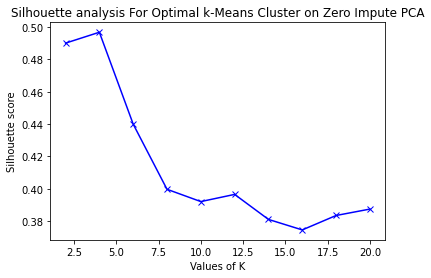

```python
range_n_clusters = [2, 4, 6, 8, 10, 12,14,16,18,20]
silhouette_avg = []
for num_clusters in range_n_clusters:
    # initialise kmeans
    kmeans = KMeans(n_clusters=num_clusters)
    kmeans.fit(X_pca.iloc[:, :2])
    cluster_labels = kmeans.labels_
    # silhouette score
    silhouette_avg.append(silhouette_score(X_pca.iloc[:, :2], cluster_labels,metric='euclidean'))
plt.plot(range_n_clusters,silhouette_avg,'bx-')
plt.xlabel('Values of K')
plt.ylabel('Silhouette score')
plt.title('Silhouette analysis For Optimal k-Means Cluster on Zero Impute PCA')
plt.show()
```

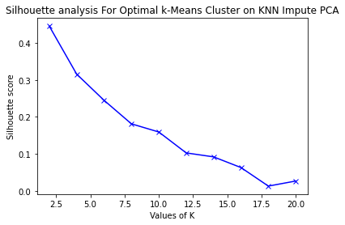

```python
range_n_clusters = [2, 4, 6, 8, 10, 12,14,16,18,20]
silhouette_avg = []
for num_clusters in range_n_clusters:
    # initialise kmeans
    kmeans = KMeans(n_clusters=num_clusters)
    kmeans.fit(X_pca_knn.iloc[:, :2])
    cluster_labels = kmeans.labels_
    # silhouette score
    silhouette_avg.append(silhouette_score(X_pca.iloc[:, :2], cluster_labels,metric='euclidean'))
plt.plot(range_n_clusters,silhouette_avg,'bx-')
plt.xlabel('Values of K')
plt.ylabel('Silhouette score')
plt.title('Silhouette analysis For Optimal k-Means Cluster on KNN Impute PCA')
plt.show()
```

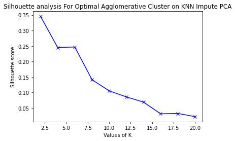

```python
range_n_clusters = [2, 4, 6, 8, 10, 12,14,16,18,20]
silhouette_avg = []
for num_clusters in range_n_clusters:
    # initialise kmeans
    clustering = AgglomerativeClustering(n_clusters=num_clusters).fit(X_pca_knn.iloc[:, :2])
    cluster_labels = clustering.labels_
    # silhouette score
    silhouette_avg.append(silhouette_score(X_pca.iloc[:, :2], cluster_labels,metric='euclidean'))
plt.plot(range_n_clusters,silhouette_avg,'bx-')
plt.xlabel('Values of K')
plt.ylabel('Silhouette score')
plt.title('Silhouette analysis For Optimal Agglomerative Cluster on KNN Impute PCA')
plt.show()
```

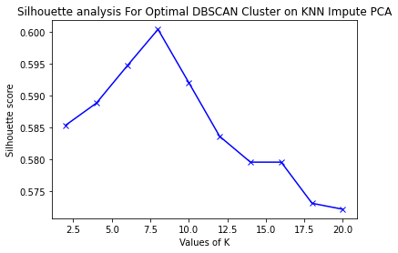

```python
range_n_clusters = [2, 4, 6, 8, 10, 12,14,16,18,20]
silhouette_avg = []
for num_clusters in range_n_clusters:
    # initialise kmeans
    clustering_dbs = DBSCAN(min_samples=num_clusters).fit(X_pca_knn.iloc[:, :2])
    cluster_labels = clustering_dbs.labels_
    # silhouette score
    silhouette_avg.append(silhouette_score(X_pca.iloc[:, :2], cluster_labels,metric='euclidean'))
plt.plot(range_n_clusters,silhouette_avg,'bx-')
plt.xlabel('Values of K')
plt.ylabel('Silhouette score')
plt.title('Silhouette analysis For Optimal DBSCAN Cluster on KNN Impute PCA')
plt.show()
```

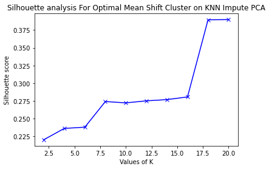

```python
range_n_clusters = [2, 4, 6, 8, 10, 12,14,16,18,20]
silhouette_avg = []
for num_clusters in range_n_clusters:
    # initialise kmeans
    clustering_ms = MeanShift(max_iter=num_clusters).fit(X_pca_knn.iloc[:, :2])
    cluster_labels = clustering_ms.labels_
    # silhouette score
    silhouette_avg.append(silhouette_score(X_pca.iloc[:, :2], cluster_labels,metric='euclidean'))
plt.plot(range_n_clusters,silhouette_avg,'bx-')
plt.xlabel('Values of K')
plt.ylabel('Silhouette score')
plt.title('Silhouette analysis For Optimal Mean Shift Cluster on KNN Impute PCA')
plt.show()
```

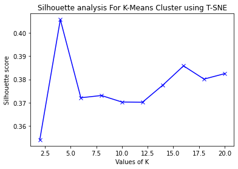

```python
range_n_clusters = [2, 4, 6, 8, 10, 12,14,16,18,20]
silhouette_avg = []
for num_clusters in range_n_clusters:
    # initialise kmeans
    kmeans = KMeans(n_clusters = num_clusters, init = 'k-means++', random_state = 42)
    cluster_labels = kmeans.fit_predict(test)
    # silhouette score
    silhouette_avg.append(silhouette_score(test, cluster_labels,metric='euclidean'))
plt.plot(range_n_clusters,silhouette_avg,'bx-')
plt.xlabel('Values of K')
plt.ylabel('Silhouette score')
plt.title('Silhouette analysis For K-Means Cluster using T-SNE')
plt.show()
```

**Results of Silhouette Analysis** The value of the Silhouette score varies from -1 to 1. If the score is 1, the cluster is dense and well-separated than other clusters. A value near 0 represents overlapping clusters with samples very close to the decision boundary of the neighboring clusters. A negative score [-1, 0] indicates that the samples might have got assigned to the wrong clusters.

- Optimal value of 'k' for k-Means Cluster on Zero Impute with PCA is around 4
- Optimal value of 'k' for k-Means Cluster on KNN Impute with PCA is around 2
- Optimal value of 'k' for Agglomerative Cluster on KNN Impute with PCA is around 2
- Optimal value of min_samples for DBSCAN Cluster on KNN Impute with PCA is around 7.5
- Optimal value of max_iter for MeanShift Cluster on KNN Impute with PCA is around 20 or more
- Optimal value of 'k' for k-Means Cluster with T-SNE is around 4